# W3cubDocs

/Matplotlib 3.5

# matplotlib.axes.Axes.scatter

**Axes.scatter(*x*, *y*, *s=None*, *c=None*, *marker=None*, *cmap=None*, *norm=None*, *vmin=None*, *vmax=None*, *alpha=None*, *linewidths=None*, *, *edgecolors=None*, *plotnonfinite=False*, *data=None*, **kwargs)[[source]](https://github.com/matplotlib/matplotlib/blob/v3.5.1/lib/matplotlib/axes/_axes.py#L4242-L4490)**

A scatter plot of *y* vs. *x* with varying marker size and/or color.

**Parameters**

**x, y**float or array-like, shape (n, )**

The data positions.

**s**float or array-like, shape (n, ), optional**

The marker size in points**2. Default is `rcParams['lines.markersize'] ** 2`.

**c**array-like or list of colors or color, optional**

The marker colors. Possible values:

- A scalar or sequence of n numbers to be mapped to colors using *cmap* and *norm*.
- A 2D array in which the rows are RGB or RGBA.
- A sequence of colors of length n.
- A single color format string.

Note that *c* should not be a single numeric RGB or RGBA sequence because that is indistinguishable from an array of values to be colormapped. If you want to specify the same RGB or RGBA value for all points, use a 2D array with a single row. Otherwise, value- matching will have precedence in case of a size matching with *x* and *y*.

If you wish to specify a single color for all points prefer the *color* keyword argument.

Defaults to [`None`](https://docs.python.org/3/library/constants.html#None). In that case the marker color is determined by the value of *color*, *facecolor* or *facecolors*. In case those are not specified or [`None`](https://docs.python.org/3/library/constants.html#None), the marker color is determined by the next color of the `Axes`' current "shape and fill" color cycle. This cycle defaults to `rcParams["axes.prop_cycle"]` (default: `cycler('color', ['#1f77b4', '#ff7f0e', '#2ca02c', '#d62728', '#9467bd', '#8c564b', '#e377c2', '#7f7f7f', '#bcbd22', '#17becf'])`).

**marker**`MarkerStyle`, default: `rcParams["scatter.marker"]` (default: `'o'`)**

The marker style. *marker* can be either an instance of the class or the text shorthand for a particular marker. See `matplotlib.markers` for more information about marker styles.

**cmap**str or `Colormap`, default: `rcParams["image.cmap"]` (default: `'viridis'`)**

A `Colormap` instance or registered colormap name. *cmap* is only used if *c* is an array of floats.

**norm**`Normalize`, default: None**

If *c* is an array of floats, *norm* is used to scale the color data, *c*, in the range 0 to 1, in order to map into the colormap *cmap*. If *None*, use the default `colors.Normalize`.

**vmin, vmax**float, default: None**

*vmin* and *vmax* are used in conjunction with the default norm to map the color array *c* to the colormap *cmap*. If None, the respective min and max of the color array is used. It is an error to use *vmin*/*vmax* when *norm* is given.

**alpha**float, default: None**

The alpha blending value, between 0 (transparent) and 1 (opaque).

**linewidths**float or array-like, default: `rcParams["lines.linewidth"]` (default: `1.5`)**

The linewidth of the marker edges. Note: The default *edgecolors* is 'face'. You may want to change this as well.

**edgecolors**{'face', 'none', *None*} or color or sequence of color, default: `rcParams["scatter.edgecolors"]` (default: `'face'`)**

The edge color of the marker. Possible values:

- 'face': The edge color will always be the same as the face color.
- 'none': No patch boundary will be drawn.
- A color or sequence of colors.

For non-filled markers, *edgecolors* is ignored. Instead, the color is determined like with 'face', i.e. from *c*, *colors*, or *facecolors*.

**plotnonfinite**bool, default: False**

Whether to plot points with nonfinite *c* (i.e. `inf`, `-inf` or `nan`). If `True` the points are drawn with the *bad* colormap color (see `Colormap.set_bad`).

**Returns**

**`PathCollection`**

**Other Parameters**

**data**indexable object, optional**

If given, the following parameters also accept a string `s`, which is interpreted as `data[s]` (unless this raises an exception):

*x*, *y*, *s*, *linewidths*, *edgecolors*, *c*, *facecolor*, *facecolors*, *color*

**kwargs`Collection` properties**

See also

**`plot`**

To plot scatter plots when markers are identical in size and color.

#### Notes

- The `plot` function will be faster for scatterplots where markers don't vary in size or color.
- Any or all of *x*, *y*, *s*, and *c* may be masked arrays, in which case all masks will be combined and only unmasked points will be plotted.
- Fundamentally, scatter works with 1D arrays; *x*, *y*, *s*, and *c* may be input as N-D arrays, but within scatter they will be flattened. The exception is *c*, which will be flattened only if its size matches the size of *x* and *y*.

## Examples using `matplotlib.axes.Axes.scatter`

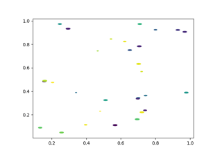

[Scatter Custom Symbol](https://matplotlib.org/3.5.1/gallery/lines_bars_and_markers/scatter_custom_symbol.html#sphx-glr-gallery-lines-bars-and-markers-scatter-custom-symbol-py)

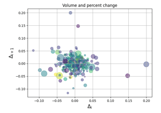

[Scatter Demo2](https://matplotlib.org/3.5.1/gallery/lines_bars_and_markers/scatter_demo2.html#sphx-glr-gallery-lines-bars-and-markers-scatter-demo2-py)

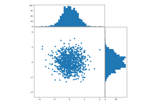

[Scatter plot with histograms](https://matplotlib.org/3.5.1/gallery/lines_bars_and_markers/scatter_hist.html#sphx-glr-gallery-lines-bars-and-markers-scatter-hist-py)

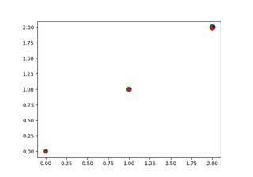

[Scatter plot with pie chart markers](https://matplotlib.org/3.5.1/gallery/lines_bars_and_markers/scatter_piecharts.html#sphx-glr-gallery-lines-bars-and-markers-scatter-piecharts-py)

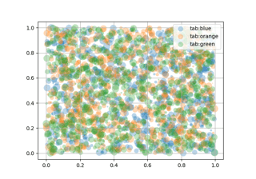

[Scatter plots with a legend](https://matplotlib.org/3.5.1/gallery/lines_bars_and_markers/scatter_with_legend.html#sphx-glr-gallery-lines-bars-and-markers-scatter-with-legend-py)

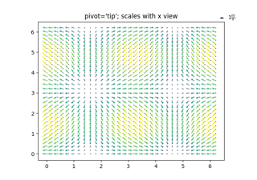

[Advanced quiver and quiverkey functions](https://matplotlib.org/3.5.1/gallery/images_contours_and_fields/quiver_demo.html#sphx-glr-gallery-images-contours-and-fields-quiver-demo-py)

[figure not shown]

[Axes box aspect](https://matplotlib.org/3.5.1/gallery/subplots_axes_and_figures/axes_box_aspect.html#sphx-glr-gallery-subplots-axes-and-figures-axes-box-aspect-py)

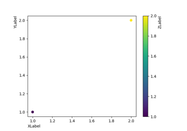

[Axis Label Position](https://matplotlib.org/3.5.1/gallery/subplots_axes_and_figures/axis_labels_demo.html#sphx-glr-gallery-subplots-axes-and-figures-axis-labels-demo-py)

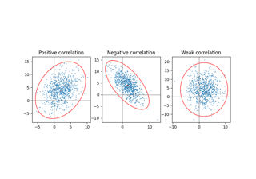

[Plot a confidence ellipse of a two-dimensional dataset](https://matplotlib.org/3.5.1/gallery/statistics/confidence_ellipse.html#sphx-glr-gallery-statistics-confidence-ellipse-py)

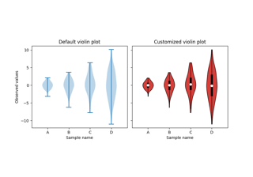

[Violin plot customization](https://matplotlib.org/3.5.1/gallery/statistics/customized_violin.html#sphx-glr-gallery-statistics-customized-violin-py)

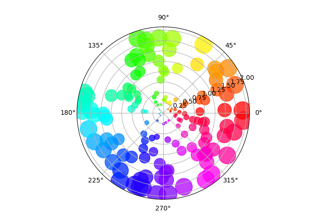

[Scatter plot on polar axis](https://matplotlib.org/3.5.1/gallery/pie_and_polar_charts/polar_scatter.html#sphx-glr-gallery-pie-and-polar-charts-polar-scatter-py)

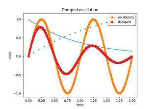

[Legend Demo](https://matplotlib.org/3.5.1/gallery/text_labels_and_annotations/legend_demo.html#sphx-glr-gallery-text-labels-and-annotations-legend-demo-py)

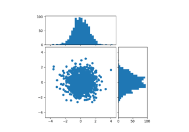

[Scatter Histogram (Locatable Axes)](https://matplotlib.org/3.5.1/gallery/axes_grid1/scatter_hist_locatable_axes.html#sphx-glr-gallery-axes-grid1-scatter-hist-locatable-axes-py)

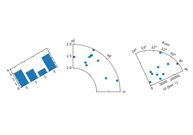

[mpl_toolkits.axisartist.floating_axes features](https://matplotlib.org/3.5.1/gallery/axisartist/demo_floating_axes.html#sphx-glr-gallery-axisartist-demo-floating-axes-py)

[figure not shown]

[Rain simulation](https://matplotlib.org/3.5.1/gallery/animation/rain.html#sphx-glr-gallery-animation-rain-py)

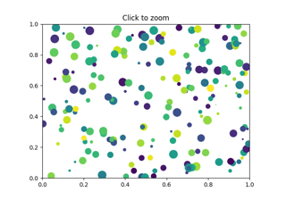

[Zoom Window](https://matplotlib.org/3.5.1/gallery/event_handling/zoom_window.html#sphx-glr-gallery-event-handling-zoom-window-py)

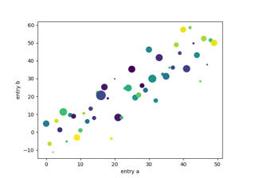

[Plotting with keywords](https://matplotlib.org/3.5.1/gallery/misc/keyword_plotting.html#sphx-glr-gallery-misc-keyword-plotting-py)

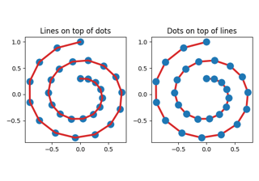

[Zorder Demo](https://matplotlib.org/3.5.1/gallery/misc/zorder_demo.html#sphx-glr-gallery-misc-zorder-demo-py)

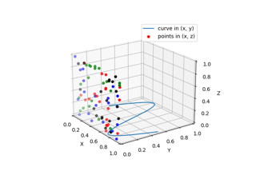

[Plot 2D data on 3D plot](https://matplotlib.org/3.5.1/gallery/mplot3d/2dcollections3d.html#sphx-glr-gallery-mplot3d-2dcollections3d-py)

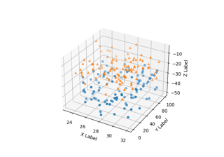

[3D scatterplot](https://matplotlib.org/3.5.1/gallery/mplot3d/scatter3d.html#sphx-glr-gallery-mplot3d-scatter3d-py)

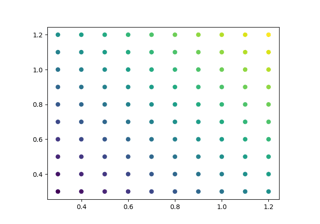

[Automatically setting tick positions](https://matplotlib.org/3.5.1/gallery/ticks/auto_ticks.html#sphx-glr-gallery-ticks-auto-ticks-py)

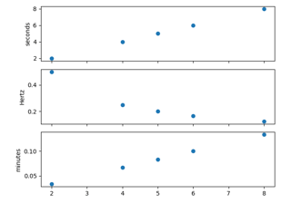

[Unit handling](https://matplotlib.org/3.5.1/gallery/units/units_scatter.html#sphx-glr-gallery-units-units-scatter-py)

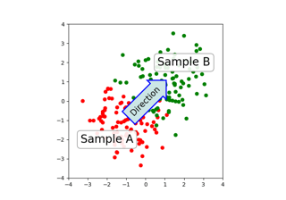

[Annotate Text Arrow](https://matplotlib.org/3.5.1/gallery/userdemo/annotate_text_arrow.html#sphx-glr-gallery-userdemo-annotate-text-arrow-py)

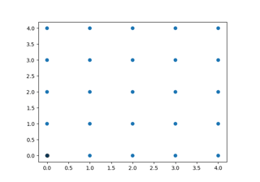

[Polygon Selector](https://matplotlib.org/3.5.1/gallery/widgets/polygon_selector_demo.html#sphx-glr-gallery-widgets-polygon-selector-demo-py)

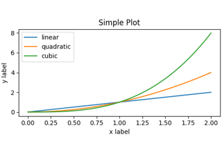

[Basic Usage](https://matplotlib.org/3.5.1/tutorials/introductory/usage.html#sphx-glr-tutorials-introductory-usage-py)

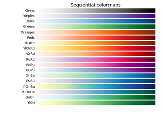

[Choosing Colormaps in Matplotlib](https://matplotlib.org/3.5.1/tutorials/colors/colormaps.html#sphx-glr-tutorials-colors-colormaps-py)

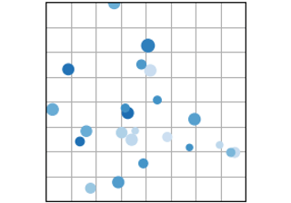

[scatter(x, y)](https://matplotlib.org/3.5.1/plot_types/basic/scatter_plot.html#sphx-glr-plot-types-basic-scatter-plot-py)

© 2012–2021 Matplotlib Development Team. All rights reserved.  
Licensed under the Matplotlib License Agreement.  
https://matplotlib.org/3.5.1/api/_as_gen/matplotlib.axes.Axes.scatter.html